# ek_counterfactuals

Aleksander Hycnar

2026-09-22

## Libraries

```r
library(here)
library(tidyverse)
```

## Question 1

### Write down the model

$$\begin{equation}
\sum_{i} X^0_{ni} = \text{total spending of } n
\label{eq:rowsum}
\end{equation}$$

$$\begin{equation}
\sum_{d} X^0_{di} = \text{total sales, hence income, of } i = w^0_i
L^0_i
\label{eq:colsum}
\end{equation}$$

$$\begin{equation}
F_i(z) = \exp\left(-T_i z^{-\theta}\right)
\label{eq:frechet}
\end{equation}$$

$$\begin{equation}
\Phi_n = \sum_{o=1}^{N} T_o \left(w_o d_{no}\right)^{-\theta},
\qquad P_n = \gamma\, \Phi_n^{-1/\theta}
\label{eq:phi}
\end{equation}$$

$$\begin{equation}
\pi_{ni} = \frac{T_i \left(w_i d_{ni}\right)^{-\theta}}{\Phi_n}
\label{eq:share}
\end{equation}$$

$$\begin{equation}
w_i L_i = \sum_{n=1}^{N} \pi_{ni} X_n
\label{eq:clearing}
\end{equation}$$

$$\begin{equation}
X_n = w_n L_n + h(w) D_n, \qquad \sum_{n=1}^{N} D_n = 0
\label{eq:budget}
\end{equation}$$

$$\begin{equation}
\pi'_{ni}
= \frac{\hat{T}_i T^0_i \left(\hat{w}_i w^0_i \,\hat{d}_{ni}
d^0_{ni}\right)^{-\theta}}
{\sum_{o} \hat{T}_o T^0_o \left(\hat{w}_o w^0_o \,\hat{d}_{no}
d^0_{no}\right)^{-\theta}}
\label{eq:pisub}
\end{equation}$$

$$\begin{equation}
\underbrace{\hat{T}_i\left(\hat{w}_i\hat{d}_{ni}\right)^{-\theta}}_{\text{hats}}
\cdot
\underbrace{T^0_i\left(w^0_i d^0_{ni}\right)^{-\theta}}_{=\ \Phi^0_n
\pi^0_{ni}}
\label{eq:factor}
\end{equation}$$

$$\begin{equation}
\hat{\pi}_{ni}
= \frac{\pi'_{ni}}{\pi^0_{ni}}
= \frac{\hat{T}_i \left(\hat{d}_{ni}\hat{w}_i\right)^{-\theta}}
{\sum_{o=1}^{N} \pi^0_{no}\, \hat{T}_o
\left(\hat{d}_{no}\hat{w}_o\right)^{-\theta}}
\label{eq:pihat}
\end{equation}$$

$$\begin{equation}
\hat{\Phi}_n = \sum_{o=1}^{N} \pi^0_{no}\, \hat{T}_o
\left(\hat{d}_{no}\hat{w}_o\right)^{-\theta},
\qquad \hat{P}_n = \hat{\Phi}_n^{-1/\theta}
\label{eq:phihat}
\end{equation}$$

$$\begin{equation}
y^0_n \equiv \frac{w^0_n L^0_n}{X^0_n}
= \frac{\sum_{i} X^0_{in}}{\sum_{i} X^0_{ni}}
\label{eq:y0}
\end{equation}$$

$$\begin{equation}
h(w^0) D_n = \left(1 - y^0_n\right) X^0_n
\label{eq:transfer}
\end{equation}$$

$$\begin{align}
w'_n L'_n &= \hat{w}_n \hat{L}_n \, w^0_n L^0_n
= \hat{w}_n \hat{L}_n \, y^0_n X^0_n \\[4pt]
h(w')D'_n &= h(w^0\hat{w})\,\hat{D}_n D_n
= \frac{h(w^0\hat{w})}{h(w^0)}\,\hat{D}_n \cdot h(w^0)D_n
= \frac{h(w^0\hat{w})}{h(w^0)}\,\hat{D}_n
\left(1-y^0_n\right) X^0_n
\label{eq:terms}
\end{align}$$

$$\begin{equation}
\frac{X'_n}{X^0_n}
= y^0_n\, \hat{w}_n \hat{L}_n
+ \left(1-y^0_n\right) \frac{h(w^0\hat{w})}{h(w^0)}\, \hat{D}_n
\label{eq:xhat}
\end{equation}$$

$$\begin{equation}
\hat{w}_i \hat{L}_i = \sum_{n=1}^{N} \frac{\pi'_{ni}
X'_n}{Y^0_i}
\label{eq:clearhat}
\end{equation}$$

$$\begin{equation}
\frac{\pi'_{ni} X'_n}{Y^0_i}
= \underbrace{\frac{\pi'_{ni}}{\pi^0_{ni}}}_{\text{Step 1}}
\cdot
\underbrace{\frac{\pi^0_{ni} X^0_n}{Y^0_i}}_{=\ X^0_{ni} / \sum_d
X^0_{di}}
\cdot
\underbrace{\frac{X'_n}{X^0_n}}_{\text{Step 2}}
\label{eq:split}
\end{equation}$$

$$\begin{equation}
Z_i(\hat{w}) \equiv
\sum_{n=1}^{N}
\frac{X^0_{ni}}{\sum_{d=1}^{N} X^0_{di}}
\cdot
\frac{\hat{T}_i\left(\hat{d}_{ni}\hat{w}_i\right)^{-\theta}}
{\sum_{o}
\pi^0_{no}\hat{T}_o\left(\hat{d}_{no}\hat{w}_o\right)^{-\theta}}
\left(
y^0_n \hat{w}_n \hat{L}_n
+ \left(1-y^0_n\right)\frac{h(w^0\hat{w})}{h(w^0)}\hat{D}_n
\right)
- \hat{w}_i \hat{L}_i
\label{eq:target}
\end{equation}$$

$$\begin{equation}
Z_i(\hat{w}) = 0 \qquad \text{for all } i
\label{eq:equil}
\end{equation}$$

## Question 2

The trade data give the matrix of bilateral flows $X^0_{ni}$ directly, with `country_dest` indexing the buyer $n$ and `country_org` the seller $i$. Row sums are total spending and column sums are total income, from which I construct the expenditure shares $\pi^0_{ni}$, the income-to-spending ratios $y^0_n$, and the share of each country’s sales going to each destination. The trade elasticity is set to $\theta = 4$.

```r
#download the data

country_list <- read_csv(here("data", "country_list.csv"))
trade <- read_csv(here("data", "bilateral_trade_country.csv"))

#set variable names
countries <- country_list$country
N         <- length(countries)

# trade elasticity, theta set to 4 as prescribed
theta <- 4

# building the matrix X0[n, i] = spending by n (destination) on goods from i (origin)
X0 <- matrix(0, nrow = N, ncol = N,
             dimnames = list(countries, countries))
X0[cbind(trade$country_dest, trade$country_org)] <- trade$trade_flow2014

# total spending of n = row sums; total income of i = column sums
spending <- rowSums(X0)
income   <- colSums(X0)

# expenditure shares pi0[n, i]
pi0 <- X0 / spending

# income-to-spending ratios
y0 <- income / spending

# share of i's sales going to n
sales_share <- t(t(X0) / income)
```

## Question 3

The shock is a 10% rise in Chinese productivity, $\hat{T}_{\text{China}} = 1.1$, with trade costs, transfers and labour forces held fixed. Transfers are denominated in US wages and the US wage is the numeraire, so $h(w^0\hat{w})/h(w^0) = 1$ and the transfer term in $Z_i$ is inert. I solve the system by iterating on excess demand until the largest $|Z_i|$ falls below $10^{-10}$.

### (a) Initial guess

```r
# shocks: 10% rise in Chinese productivity, nothing else
That <- rep(1, N)
names(That) <- countries
That["CHN"] <- 1.1

Dhat <- rep(1, N)
Lhat <- rep(1, N)

# h(w) = w_US and what_US = 1, so the numeraire ratio is one
h_ratio <- 1

# step b = 0: guess what_i = 1 for all i
what <- rep(1, N)
names(what) <- countries

# US wage is the numeraire, fixed at 1 throughout
what["USA"] <- 1

what
```

```
## AUS AUT BEL BGR BRA CAN CHE CHN CZE DEU DNK ESP EST FIN FRA GBR GRC HRV HUN IDN
##   1   1   1   1   1   1   1   1   1   1   1   1   1   1   1   1   1   1   1   1
## IND IRL ITA JPN KOR LTU LVA MEX NLD NOR POL PRT ROU ROW RUS SVK SVN SWE TUR TWN
##   1   1   1   1   1   1   1   1   1   1   1   1   1   1   1   1   1   1   1   1
## USA
##   1
```

### (b) Iteration

```r
kappa <- 0.5
tol   <- 1e-10
B     <- 100000

# store the error at each step
err_path <- rep(NA, B)

what <- rep(1, N)
names(what) <- countries

for (b in 1:B) {

  Phihat <- as.vector(pi0 %*% (That * what^(-theta)))
  pihat  <- matrix(That * what^(-theta), nrow = N, ncol = N, byrow = TRUE) / Phihat
  Xhat   <- y0 * what * Lhat + (1 - y0) * h_ratio * Dhat

  Z <- colSums(sales_share * pihat * Xhat) - what * Lhat
  Z["USA"] <- 0

  err_path[b] <- max(abs(Z))

  if (err_path[b] < tol) break

  what <- what + kappa * Z
  what["USA"] <- 1
}

err_path <- err_path[1:b]

b
```

```
## [1] 258
```

```r
err_path[b]
```

```
## [1] 9.963497e-11
```

### Convergence check

The maximum error falls monotonically at every step, from $1.2 \times 10^{-2}$ to below tolerance in 258 iterations. On a log scale the decline is close to linear, which is what a well-chosen $\kappa$ should produce.

```r
# error falls monotonically at every step
all(diff(err_path) < 0)
```

```
## [1] TRUE
```

```r
# first few and last few errors
head(err_path)
```

```
## [1] 0.012416770 0.007537234 0.004942981 0.003368680 0.002370837 0.001720655
```

```r
tail(err_path)
```

```
## [1] 1.356797e-10 1.275533e-10 1.199154e-10 1.127336e-10 1.059826e-10
## [6] 9.963497e-11
```

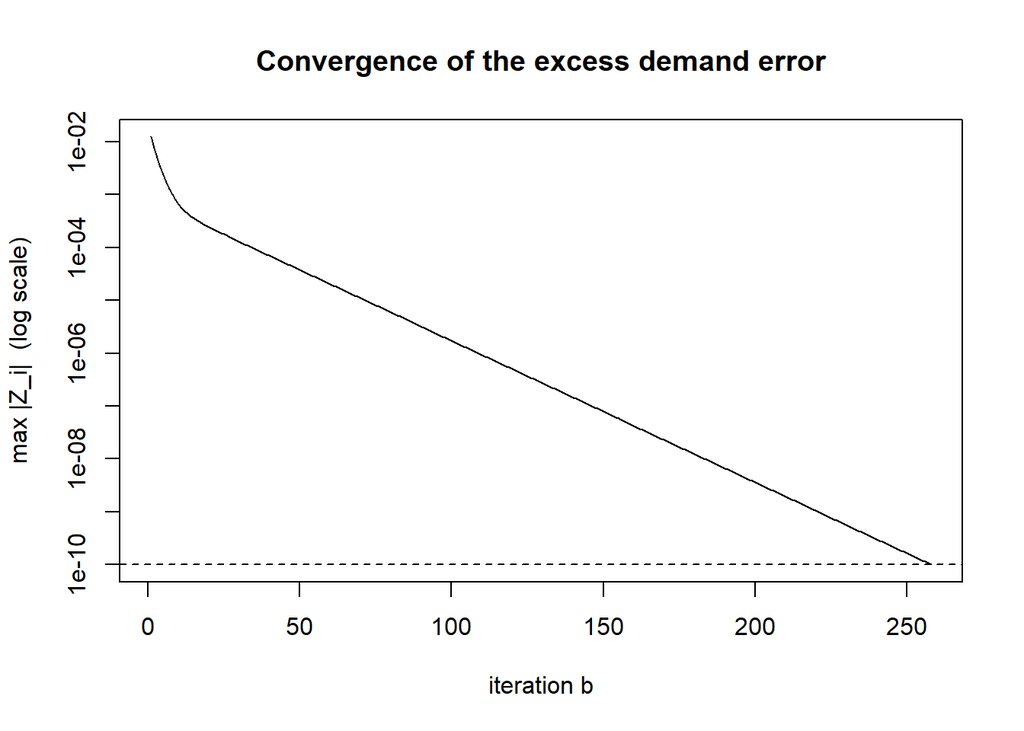

```r
# log scale makes the geometric decline visible
plot(err_path, type = "l", log = "y",
     xlab = "iteration b",
     ylab = "max |Z_i|  (log scale)",
     main = "Convergence of the excess demand error")
abline(h = tol, lty = 2)
```

## Question 4

### Real wage and real expenditure

```r
# change in market access and price index
Phihat <- as.vector(pi0 %*% (That * what^(-theta)))
Phat   <- Phihat^(-1 / theta)
names(Phihat) <- countries
names(Phat)   <- countries

# change in total spending
Xhat <- y0 * what * Lhat + (1 - y0) * h_ratio * Dhat

# change in domestic trade share
pihat <- matrix(That * what^(-theta), nrow = N, ncol = N, byrow = TRUE) / Phihat
dimnames(pihat) <- list(countries, countries)
pihat_ii <- diag(pihat)

# initial spending share on Chinese goods
pi0_china <- pi0[, "CHN"]

results <- data.frame(
  country   = countries,
  what      = what,
  Xhat      = Xhat,
  Phat      = Phat,
  real_wage = what / Phat,
  real_exp  = Xhat / Phat,
  pihat_ii  = pihat_ii,
  Phihat    = Phihat,
  pi0_china = pi0_china
)

results[order(-results$real_wage), ]
```

```
##     country      what      Xhat      Phat real_wage real_exp  pihat_ii
## CHN     CHN 1.0217721 1.0221792 0.9978595  1.023964 1.024372 1.0005851
## TWN     TWN 1.0005778 1.0006164 1.0003787  1.000199 1.000238 0.9992044
## KOR     KOR 1.0003699 1.0003852 1.0002556  1.000114 1.000130 0.9995428
## ROW     ROW 1.0001650 1.0001572 1.0000628  1.000102 1.000094 0.9995916
## AUS     AUS 1.0003551 1.0003549 1.0002894  1.000066 1.000066 0.9997370
## NLD     NLD 1.0000749 1.0000809 1.0000205  1.000054 1.000060 0.9997823
## JPN     JPN 1.0001509 1.0001497 1.0001042  1.000047 1.000045 0.9998132
## DEU     DEU 1.0001611 1.0001705 1.0001177  1.000043 1.000053 0.9998262
## IDN     IDN 1.0001164 1.0001169 1.0000732  1.000043 1.000044 0.9998274
## RUS     RUS 1.0000630 1.0000653 1.0000230  1.000040 1.000042 0.9998397
## HUN     HUN 1.0001027 1.0001069 1.0000648  1.000038 1.000042 0.9998483
## CZE     CZE 1.0000889 1.0000926 1.0000550  1.000034 1.000038 0.9998643
## FIN     FIN 1.0001022 1.0001028 1.0000710  1.000031 1.000032 0.9998752
## DNK     DNK 1.0001400 1.0001464 1.0001095  1.000031 1.000037 0.9998780
## EST     EST 1.0000547 1.0000549 1.0000252  1.000030 1.000030 0.9998818
## IRL     IRL 1.0001101 1.0001225 1.0000808  1.000029 1.000042 0.9998825
## CAN     CAN 1.0000035 1.0000035 0.9999764  1.000027 1.000027 0.9998916
## BRA     BRA 1.0001722 1.0001702 1.0001465  1.000026 1.000024 0.9998973
## SWE     SWE 1.0001022 1.0001055 1.0000766  1.000026 1.000029 0.9998975
## MEX     MEX 0.9999688 0.9999687 0.9999443  1.000024 1.000024 0.9999020
## SVK     SVK 1.0001402 1.0001447 1.0001163  1.000024 1.000028 0.9999045
## BEL     BEL 1.0001025 1.0001060 1.0000788  1.000024 1.000027 0.9999051
## TUR     TUR 1.0000297 1.0000301 1.0000078  1.000022 1.000022 0.9999123
## SVN     SVN 1.0000778 1.0000796 1.0000574  1.000020 1.000022 0.9999183
## POL     POL 1.0000681 1.0000693 1.0000483  1.000020 1.000021 0.9999210
## GBR     GBR 1.0000803 1.0000800 1.0000614  1.000019 1.000019 0.9999243
## FRA     FRA 1.0001018 1.0001014 1.0000834  1.000018 1.000018 0.9999267
## IND     IND 1.0000598 1.0000598 1.0000415  1.000018 1.000018 0.9999268
## USA     USA 1.0000000 1.0000000 0.9999818  1.000018 1.000018 0.9999273
## BGR     BGR 1.0001019 1.0000996 1.0000847  1.000017 1.000015 0.9999310
## CHE     CHE 1.0001289 1.0001375 1.0001133  1.000016 1.000024 0.9999376
## AUT     AUT 1.0001388 1.0001417 1.0001234  1.000015 1.000018 0.9999382
## ITA     ITA 1.0000956 1.0000973 1.0000812  1.000014 1.000016 0.9999421
## NOR     NOR 1.0001148 1.0001240 1.0001005  1.000014 1.000023 0.9999430
## LVA     LVA 1.0000548 1.0000541 1.0000415  1.000013 1.000013 0.9999470
## ESP     ESP 1.0000675 1.0000677 1.0000553  1.000012 1.000012 0.9999508
## LTU     LTU 1.0000684 1.0000703 1.0000564  1.000012 1.000014 0.9999518
## GRC     GRC 1.0000486 1.0000464 1.0000385  1.000010 1.000008 0.9999594
## ROU     ROU 1.0000829 1.0000830 1.0000736  1.000009 1.000009 0.9999628
```

[output cut: 29 more lines]

```
## FRA 0.9996663 0.008197795
## IND 0.9998340 0.011255507
## USA 1.0000727 0.011039487
## BGR 0.9996615 0.008185023
## CHE 0.9995468 0.005547591
## AUT 0.9995066 0.005346894
## ITA 0.9996754 0.007204193
## NOR 0.9995979 0.005885384
## LVA 0.9998339 0.009941231
## ESP 0.9997790 0.008393259
## LTU 0.9997745 0.011284320
## GRC 0.9998461 0.010651179
## ROU 0.9997056 0.006568035
## HRV 0.9997226 0.007353824
## PRT 0.9996987 0.005348431
```

China’s real wage rises 2.4%. Every other country gains, but by less than 0.02%. Mexico is the only country whose nominal wage falls, since it competes directly with China in the US market; its real wage still rises because its price index falls further.

### Regressions

```r
# drop China
reg_data <- subset(results, country != "CHN")

reg_data$ln_real_wage <- log(reg_data$real_wage)
reg_data$ln_real_exp  <- log(reg_data$real_exp)
reg_data$ln_pihat_ii  <- log(reg_data$pihat_ii)
reg_data$ln_Phihat    <- log(reg_data$Phihat)

# real wage on each regressor separately
summary(lm(ln_real_wage ~ ln_pihat_ii, data = reg_data))
```

```
##
## Call:
## lm(formula = ln_real_wage ~ ln_pihat_ii, data = reg_data)
##
## Residuals:
##        Min         1Q     Median         3Q        Max
## -1.454e-16 -6.033e-17  1.974e-18  5.187e-17  1.507e-16
##
## Coefficients:
##               Estimate Std. Error    t value Pr(>|t|)
## (Intercept)  1.831e-17  1.829e-17  1.001e+00    0.323
## ln_pihat_ii -2.500e-01  9.506e-14 -2.630e+12   <2e-16 ***
## ---
## Signif. codes:  0 '***' 0.001 '**' 0.01 '*' 0.05 '.' 0.1 ' ' 1
##
## Residual standard error: 8.315e-17 on 38 degrees of freedom
## Multiple R-squared:      1,  Adjusted R-squared:      1
## F-statistic: 6.916e+24 on 1 and 38 DF,  p-value: < 2.2e-16
```

```r
summary(lm(ln_real_wage ~ ln_Phihat,   data = reg_data))
```

```
##
## Call:
## lm(formula = ln_real_wage ~ ln_Phihat, data = reg_data)
##
## Residuals:
##        Min         1Q     Median         3Q        Max
## -3.263e-05 -1.756e-05 -5.850e-06  1.175e-05  7.455e-05
##
## Coefficients:
##               Estimate Std. Error t value Pr(>|t|)
## (Intercept)  7.924e-06  5.838e-06   1.357    0.183
## ln_Phihat   -7.816e-02  1.299e-02  -6.019 5.36e-07 ***
## ---
## Signif. codes:  0 '***' 0.001 '**' 0.01 '*' 0.05 '.' 0.1 ' ' 1
##
## Residual standard error: 2.538e-05 on 38 degrees of freedom
## Multiple R-squared:  0.4881, Adjusted R-squared:  0.4746
## F-statistic: 36.23 on 1 and 38 DF,  p-value: 5.358e-07
```

```r
summary(lm(ln_real_wage ~ pi0_china,   data = reg_data))
```

```
##
## Call:
## lm(formula = ln_real_wage ~ pi0_china, data = reg_data)
##
## Residuals:
##        Min         1Q     Median         3Q        Max
## -2.819e-05 -1.164e-05  1.100e-08  9.331e-06  7.780e-05
##
## Coefficients:
##               Estimate Std. Error t value Pr(>|t|)
## (Intercept) -1.825e-05  5.814e-06  -3.138  0.00328 **
## pi0_china    3.660e-03  3.572e-04  10.247 1.73e-12 ***
## ---
## Signif. codes:  0 '***' 0.001 '**' 0.01 '*' 0.05 '.' 0.1 ' ' 1
##
## Residual standard error: 1.829e-05 on 38 degrees of freedom
## Multiple R-squared:  0.7343, Adjusted R-squared:  0.7273
## F-statistic:   105 on 1 and 38 DF,  p-value: 1.727e-12
```

```r
# real expenditure on each regressor separately
summary(lm(ln_real_exp ~ ln_pihat_ii, data = reg_data))
```

```
##
## Call:
## lm(formula = ln_real_exp ~ ln_pihat_ii, data = reg_data)
##
## Residuals:
##        Min         1Q     Median         3Q        Max
## -2.055e-05 -1.853e-06  7.280e-08  1.500e-06  1.203e-05
##
## Coefficients:
##               Estimate Std. Error t value Pr(>|t|)
## (Intercept) -1.764e-06  1.154e-06  -1.528    0.135
## ln_pihat_ii -2.856e-01  6.000e-03 -47.606   <2e-16 ***
## ---
## Signif. codes:  0 '***' 0.001 '**' 0.01 '*' 0.05 '.' 0.1 ' ' 1
##
## Residual standard error: 5.248e-06 on 38 degrees of freedom
## Multiple R-squared:  0.9835, Adjusted R-squared:  0.9831
## F-statistic:  2266 on 1 and 38 DF,  p-value: < 2.2e-16
```

```r
summary(lm(ln_real_exp ~ ln_Phihat,   data = reg_data))
```

```
##
## Call:
## lm(formula = ln_real_exp ~ ln_Phihat, data = reg_data)
##
## Residuals:
##        Min         1Q     Median         3Q        Max
## -4.853e-05 -2.006e-05 -5.411e-06  1.227e-05  9.017e-05
##
## Coefficients:
##               Estimate Std. Error t value Pr(>|t|)
## (Intercept)  5.946e-06  6.476e-06   0.918    0.364
## ln_Phihat   -9.343e-02  1.441e-02  -6.485 1.23e-07 ***
## ---
## Signif. codes:  0 '***' 0.001 '**' 0.01 '*' 0.05 '.' 0.1 ' ' 1
##
## Residual standard error: 2.816e-05 on 38 degrees of freedom
## Multiple R-squared:  0.5253, Adjusted R-squared:  0.5128
## F-statistic: 42.05 on 1 and 38 DF,  p-value: 1.234e-07
```

```r
summary(lm(ln_real_exp ~ pi0_china,   data = reg_data))
```

```
##
## Call:
## lm(formula = ln_real_exp ~ pi0_china, data = reg_data)
##
## Residuals:
##        Min         1Q     Median         3Q        Max
## -3.904e-05 -1.517e-05 -1.245e-06  8.620e-06  1.059e-04
##
## Coefficients:
##               Estimate Std. Error t value Pr(>|t|)
## (Intercept) -1.967e-05  7.665e-06  -2.567   0.0143 *
## pi0_china    3.974e-03  4.709e-04   8.439 3.06e-10 ***
## ---
## Signif. codes:  0 '***' 0.001 '**' 0.01 '*' 0.05 '.' 0.1 ' ' 1
##
## Residual standard error: 2.411e-05 on 38 degrees of freedom
## Multiple R-squared:  0.6521, Adjusted R-squared:  0.6429
## F-statistic: 71.21 on 1 and 38 DF,  p-value: 3.055e-10
```

The regression of the log real wage on $\ln\hat{\pi}_{ii}$ returns a coefficient of exactly $-0.25$ with $R^2 = 1$. This is not an empirical finding but an identity: for every country other than China $\hat{T}_i = 1$, so $\hat{\pi}_{ii} = \hat{w}_i^{-\theta}/\hat{\Phi}_i$ and $\hat{\pi}_{ii}^{-1/\theta} = \hat{w}_i/\hat{P}_i$. The estimate recovers $-1/\theta$ because the model says it must. I take the exact fit as a check that the solver is coded correctly.

Market access enters with a negative coefficient, which looks wrong until one notices that $\hat{\Phi}_i$ is endogenous. Each country carries a large weight in its own $\Phi$, so a country whose wage rises sees its own $\hat{\Phi}$ fall. Taiwan has both the largest real wage gain and the lowest $\hat{\Phi}$. The partial effect of market access is positive, but the regression picks up the correlation with $\hat{w}_i$ and reverses the sign.

The initial Chinese import share gives the cleanest result: a coefficient of 0.0037 with an $R^2$ of 0.73. Countries that bought more from China to begin with gain more, because the productivity improvement reaches them through cheaper imports in proportion to how much of their spending goes to Chinese goods. The real expenditure regressions behave the same way, except that the coefficient on $\ln\hat{\pi}_{ii}$ is $-0.286$ rather than $-0.25$. The ACR identity holds for real income, not real expenditure, and the gap between them is the transfer.

## Question 5

### Solve with the Chinese wage as the transfer numeraire

```r
kappa <- 0.5
tol   <- 1e-10
B     <- 100000

# store the error at each step
err_path2 <- rep(NA, B)

what2 <- rep(1, N)
names(what2) <- countries

for (b in 1:B) {

  Phihat2 <- as.vector(pi0 %*% (That * what2^(-theta)))
  pihat2  <- matrix(That * what2^(-theta), nrow = N, ncol = N, byrow = TRUE) / Phihat2

  # h(w0 what) / h(w0) = what_China
  h_ratio2 <- what2["CHN"]

  Xhat2 <- y0 * what2 * Lhat + (1 - y0) * h_ratio2 * Dhat

  Z2 <- colSums(sales_share * pihat2 * Xhat2) - what2 * Lhat
  Z2["USA"] <- 0

  err_path2[b] <- max(abs(Z2))

  if (err_path2[b] < tol) break

  what2 <- what2 + kappa * Z2
  what2["USA"] <- 1
}

err_path2 <- err_path2[1:b]

b
```

```
## [1] 247
```

```r
err_path2[b]
```

```
## [1] 9.779999e-11
```

### Convergence check

```r
all(diff(err_path2) < 0)
```

```
## [1] TRUE
```

```r
head(err_path2)
```

```
## [1] 0.012416770 0.007436664 0.004824783 0.003253452 0.002264340 0.001623858
```

```r
tail(err_path2)
```

```
## [1] 1.347487e-10 1.263822e-10 1.185363e-10 1.111762e-10 1.042735e-10
## [6] 9.779999e-11
```

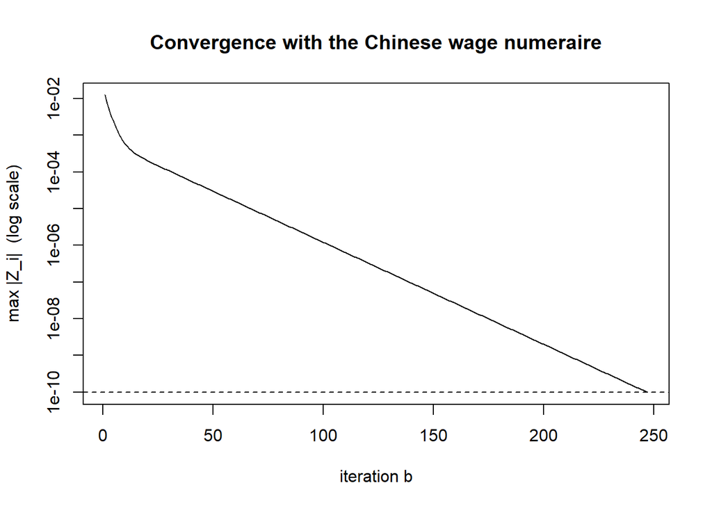

```r
plot(err_path2, type = "l", log = "y",
     xlab = "iteration b",
     ylab = "max |Z_i|  (log scale)",
     main = "Convergence with the Chinese wage numeraire")
abline(h = tol, lty = 2)
```

### Real variables

```r
Phihat2 <- as.vector(pi0 %*% (That * what2^(-theta)))
Phat2   <- Phihat2^(-1 / theta)
names(Phat2) <- countries

h_ratio2 <- what2["CHN"]
Xhat2    <- y0 * what2 * Lhat + (1 - y0) * h_ratio2 * Dhat

results2 <- data.frame(
  country    = countries,
  what2      = what2,
  Phat2      = Phat2,
  real_wage2 = what2 / Phat2,
  real_exp2  = Xhat2 / Phat2
)

results2[order(-results2$real_wage2), ]
```

```
##     country     what2     Phat2 real_wage2 real_exp2
## CHN     CHN 1.0207594 0.9969024  1.0239312 1.0239312
## ROW     ROW 1.0000556 0.9998356  1.0002200 1.0011936
## GRC     GRC 1.0001302 0.9999770  1.0001531 1.0011054
## BGR     BGR 0.9995779 0.9995001  1.0000779 1.0005578
## TWN     TWN 0.9996286 0.9995583  1.0000703 0.9986558
## JPN     JPN 0.9998636 0.9997959  1.0000677 1.0002393
## AUS     AUS 0.9998694 0.9998029  1.0000665 1.0000792
## PRT     PRT 0.9996527 0.9995883  1.0000643 1.0003976
## USA     USA 1.0000000 0.9999410  1.0000590 1.0003761
## LVA     LVA 0.9993389 0.9992808  1.0000581 1.0003362
## BRA     BRA 1.0000795 1.0000244  1.0000551 1.0002897
## MEX     MEX 0.9997403 0.9996983  1.0000420 0.9999755
## GBR     GBR 0.9994647 0.9994239  1.0000407 1.0001150
## HRV     HRV 0.9993385 0.9992986  1.0000400 0.9999658
## IDN     IDN 0.9996314 0.9995933  1.0000380 0.9999441
## KOR     KOR 0.9994445 0.9994088  1.0000358 0.9991537
## FRA     FRA 0.9994001 0.9993667  1.0000334 1.0001042
## CAN     CAN 0.9997378 0.9997049  1.0000329 0.9999102
## FIN     FIN 0.9991751 0.9991442  1.0000309 0.9999033
## EST     EST 0.9991410 0.9991111  1.0000299 0.9999659
## IND     IND 0.9997589 0.9997320  1.0000269 1.0000414
## ROU     ROU 0.9992650 0.9992469  1.0000181 0.9999982
## ESP     ESP 0.9993833 0.9993679  1.0000154 0.9999584
## TUR     TUR 0.9992544 0.9992455  1.0000089 0.9997222
## LTU     LTU 0.9992114 0.9992141  0.9999973 0.9994113
## RUS     RUS 0.9989123 0.9989176  0.9999947 0.9992253
## AUT     AUT 0.9989963 0.9990111  0.9999852 0.9995387
## ITA     ITA 0.9990798 0.9990955  0.9999843 0.9996112
## POL     POL 0.9989084 0.9989261  0.9999822 0.9995981
## SVN     SVN 0.9990463 0.9990697  0.9999766 0.9994644
## SWE     SWE 0.9989493 0.9989741  0.9999752 0.9992769
## DNK     DNK 0.9990364 0.9990666  0.9999697 0.9989810
## HUN     HUN 0.9989745 0.9990089  0.9999655 0.9990927
## BEL     BEL 0.9991831 0.9992235  0.9999595 0.9992277
## SVK     SVK 0.9989926 0.9990378  0.9999547 0.9992581
## CZE     CZE 0.9988078 0.9988578  0.9999500 0.9990508
## DEU     DEU 0.9988330 0.9988834  0.9999495 0.9986667
## CHE     CHE 0.9988637 0.9989315  0.9999321 0.9984804
## NOR     NOR 0.9985504 0.9986540  0.9998962 0.9981072
## NLD     NLD 0.9987958 0.9989052  0.9998905 0.9981303
## IRL     IRL 0.9992711 0.9994234  0.9998476 0.9974293
```

### Comparison with item 1.iii

```r
compare <- data.frame(
  country        = countries,
  y0             = y0,
  real_wage_US   = results$real_wage,
  real_wage_CHN  = results2$real_wage2,
  diff_wage      = results2$real_wage2 - results$real_wage,
  real_exp_US    = results$real_exp,
  real_exp_CHN   = results2$real_exp2,
  diff_exp       = results2$real_exp2 - results$real_exp
)

compare[order(-abs(compare$diff_wage)), ]
```

```
##     country        y0 real_wage_US real_wage_CHN     diff_wage real_exp_US
## IRL     IRL 1.1124734     1.000029     0.9998476 -1.817810e-04    1.000042
## NLD     NLD 1.0800536     1.000054     0.9998905 -1.639583e-04    1.000060
## GRC     GRC 0.9538387     1.000010     1.0001531  1.429796e-04    1.000008
## TWN     TWN 1.0669121     1.000199     1.0000703 -1.286510e-04    1.000238
## NOR     NOR 1.0804442     1.000014     0.9998962 -1.180121e-04    1.000023
## ROW     ROW 0.9529827     1.000102     1.0002200  1.178235e-04    1.000094
## DEU     DEU 1.0584401     1.000043     0.9999495 -9.389657e-05    1.000053
## CZE     CZE 1.0409188     1.000034     0.9999500 -8.391082e-05    1.000038
## CHE     CHE 1.0662274     1.000016     0.9999321 -8.352362e-05    1.000024
## KOR     KOR 1.0413576     1.000114     1.0000358 -7.853168e-05    1.000130
## HUN     HUN 1.0400262     1.000038     0.9999655 -7.242946e-05    1.000042
## SVK     SVK 1.0319728     1.000024     0.9999547 -6.918146e-05    1.000028
## BEL     BEL 1.0338948     1.000024     0.9999595 -6.416889e-05    1.000027
## DNK     DNK 1.0454711     1.000031     0.9999697 -6.076706e-05    1.000037
## BGR     BGR 0.9773511     1.000017     1.0000779  6.059999e-05    1.000015
## PRT     PRT 0.9842179     1.000008     1.0000643  5.651092e-05    1.000007
## SWE     SWE 1.0319851     1.000026     0.9999752 -5.042733e-05    1.000029
## RUS     RUS 1.0351818     1.000040     0.9999947 -4.535966e-05    1.000042
## LVA     LVA 0.9870279     1.000013     1.0000581  4.488386e-05    1.000013
## SVN     SVN 1.0235638     1.000020     0.9999766 -4.385891e-05    1.000022
## USA     USA 0.9847246     1.000018     1.0000590  4.083495e-05    1.000018
## POL     POL 1.0175580     1.000020     0.9999822 -3.756655e-05    1.000021
## CHN     CHN 1.0186963     1.023964     1.0239312 -3.277188e-05    1.024372
## HRV     HRV 1.0034629     1.000008     1.0000400  3.203379e-05    1.000008
## AUT     AUT 1.0204947     1.000015     0.9999852 -3.027644e-05    1.000018
## ITA     ITA 1.0171978     1.000014     0.9999843 -3.014168e-05    1.000016
## BRA     BRA 0.9886575     1.000026     1.0000551  2.942820e-05    1.000024
## GBR     GBR 0.9965166     1.000019     1.0000407  2.181393e-05    1.000019
## JPN     JPN 0.9917930     1.000047     1.0000677  2.103252e-05    1.000045
## MEX     MEX 1.0031638     1.000024     1.0000420  1.747824e-05    1.000024
## FRA     FRA 0.9966876     1.000018     1.0000334  1.505396e-05    1.000018
## LTU     LTU 1.0271723     1.000012     0.9999973 -1.477307e-05    1.000014
## TUR     TUR 1.0133227     1.000022     1.0000089 -1.298856e-05    1.000022
## ROU     ROU 1.0009249     1.000009     1.0000181  8.834903e-06    1.000009
## IND     IND 0.9993101     1.000018     1.0000269  8.593701e-06    1.000018
## CAN     CAN 1.0058330     1.000027     1.0000329  5.798769e-06    1.000027
## IDN     IDN 1.0044427     1.000043     1.0000380 -5.131607e-06    1.000044
## ESP     ESP 1.0026627     1.000012     1.0000154  3.102481e-06    1.000012
## AUS     AUS 0.9993927     1.000066     1.0000665  7.881373e-07    1.000066
```

[output cut: 29 more lines]

```
## BRA    1.0002897  2.659368e-04
## GBR    1.0001150  9.631545e-05
## JPN    1.0002393  1.937991e-04
## MEX    0.9999755 -4.894421e-05
## FRA    1.0001042  8.618611e-05
## LTU    0.9994113 -6.026031e-04
## TUR    0.9997222 -3.001045e-04
## ROU    0.9999982 -1.113637e-05
## IND    1.0000414  2.312671e-05
## CAN    0.9999102 -1.168778e-04
## IDN    0.9999441 -9.955297e-05
## ESP    0.9999584 -5.403094e-05
## AUS    1.0000792  1.369267e-05
## EST    0.9999659 -6.383361e-05
## FIN    0.9999033 -1.285292e-04
```

```r
# the difference lines up with the sign of the trade imbalance
cor(compare$diff_wage, compare$y0)
```

```
## [1] -0.9752906
```

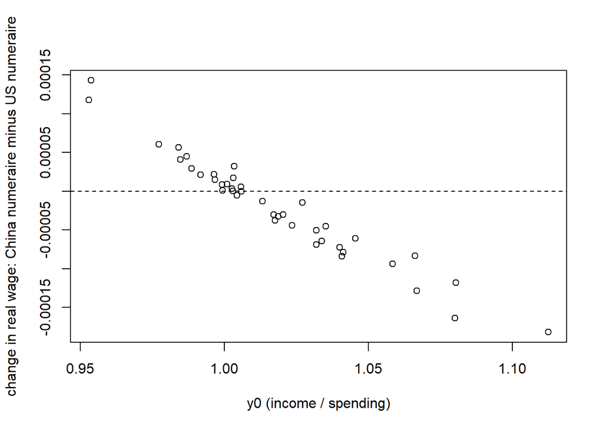

```r
plot(compare$y0, compare$diff_wage,
     xlab = "y0 (income / spending)",
     ylab = "change in real wage: China numeraire minus US numeraire")
abline(h = 0, lty = 2)
```

The magnitudes are small here because 2014 imbalances are modest, with $y^0$ ranging from 0.95 to 1.11. The point is that the choice of $h(w)$ is not a harmless normalisation. It fixes the real value of international transfers and therefore redistributes between debtors and creditors.